# Анализ данных о продажах компьютерных игр

Интернет-магазин «Стримчик» занимается продажей компьютерных игр по всему миру. Из открытых источников доступны исторические данные о продажах игр, оценки пользователей и экспертов, жанры и платформы (например, `Xbox` или `PlayStation`).

Необходимо выявить определяющие успешность игры закономерности. Это позволит сделать ставку на потенциально популярный продукт и спланировать рекламные кампании.

В наборе данных попадается аббревиатура `ESRB (Entertainment Software Rating Board)` — это ассоциация, определяющая возрастной рейтинг компьютерных игр. ESRB оценивает игровой контент и присваивает ему подходящую возрастную категорию, например, «Для взрослых», «Для детей младшего возраста» или «Для подростков».

**Описание данных:**

- `Name` — название игры
- `Platform` — платформа
- `Year_of_Release` — год выпуска
- `Genre` — жанр игры
- `NA_sales` — продажи в Северной Америке (миллионы проданных копий)
- `EU_sales` — продажи в Европе (миллионы проданных копий)
- `JP_sales` — продажи в Японии (миллионы проданных копий)
- `Other_sales` — продажи в других странах (миллионы проданных копий)
- `Critic_Score` — оценка критиков (максимум 100)
- `User_Score` — оценка пользователей (максимум 10)
- `Rating` — рейтинг от организации ESRB (англ. Entertainment Software Rating Board). Эта ассоциация определяет рейтинг компьютерных игр и присваивает им подходящую возрастную категорию.

**План исследования:**

1. Изучим общую информацию в датасете
2. Подготовим данные:
   - приведем названия столбцов к нижнему регистру,
   - проверим данные на пропуски,
   - преобразуем типы данных,
   - посчитаем суммарные продажи во всех регионах и выделим их в отдельный столбец.
3. Проведем исследовательский анализ данных:
   - анализ выпущенных игр по годам,
   - анализ продаж по платформам,
   - определим актуальный период для анализа данных,
   - сделаем выборку потенциально прибыльных платформ,
   - проверим как влияют на продажи отзывы пользователей и критиков,
   - анализ игр по жанрам.
4. Составим портрет пользователя по регионам:
   - выявим топ-5 платформ,
   - выявим топ-5 жанров,
   - выясним, влияет ли рейтинг ESRB на продажи в отдельном регионе.
5. Проверим две гипотезы:
   - о равенстве средних пользовательских рейтингов платформ Xbox One и PC,
   - о разности средних пользовательских рейтингов жанров Action и Sports.
6. Сформулируем общий вывод по исследованию.

## Изучение общей информации

```python
# импортируем библиотеки
import pandas as pd
import numpy as np
import matplotlib.pyplot as plt
import seaborn as sns
from scipy import stats as st
```

```python
pd.set_option('display.max_columns', None)
```

```python
# прочитаем файл
try:
    data = pd.read_csv('games.csv')
except:
    data = pd.read_csv('https://code.s3.yandex.net/datasets/games.csv')
data.head()
```

|  | Name | Platform | Year_of_Release | Genre | NA_sales | EU_sales | JP_sales | Other_sales | Critic_Score | User_Score | Rating |
| --- | --- | --- | --- | --- | --- | --- | --- | --- | --- | --- | --- |
| 0 | Wii Sports | Wii | 2006.0 | Sports | 41.36 | 28.96 | 3.77 | 8.45 | 76.0 | 8 | E |
| 1 | Super Mario Bros. | NES | 1985.0 | Platform | 29.08 | 3.58 | 6.81 | 0.77 | NaN | NaN | NaN |
| 2 | Mario Kart Wii | Wii | 2008.0 | Racing | 15.68 | 12.76 | 3.79 | 3.29 | 82.0 | 8.3 | E |
| 3 | Wii Sports Resort | Wii | 2009.0 | Sports | 15.61 | 10.93 | 3.28 | 2.95 | 80.0 | 8 | E |
| 4 | Pokemon Red/Pokemon Blue | GB | 1996.0 | Role-Playing | 11.27 | 8.89 | 10.22 | 1.00 | NaN | NaN | NaN |

```python
# выведем общую информацию
data.info()
```

```
<class 'pandas.core.frame.DataFrame'>
RangeIndex: 16715 entries, 0 to 16714
Data columns (total 11 columns):
 #   Column           Non-Null Count  Dtype
---  ------           --------------  -----
 0   Name             16713 non-null  object
 1   Platform         16715 non-null  object
 2   Year_of_Release  16446 non-null  float64
 3   Genre            16713 non-null  object
 4   NA_sales         16715 non-null  float64
 5   EU_sales         16715 non-null  float64
 6   JP_sales         16715 non-null  float64
 7   Other_sales      16715 non-null  float64
 8   Critic_Score     8137 non-null   float64
 9   User_Score       10014 non-null  object
 10  Rating           9949 non-null   object
dtypes: float64(6), object(5)
memory usage: 1.4+ MB
```

```python
# проверка на количество пропусков
data.isna().sum()
```

```
Name                  2
Platform              0
Year_of_Release     269
Genre                 2
NA_sales              0
EU_sales              0
JP_sales              0
Other_sales           0
Critic_Score       8578
User_Score         6701
Rating             6766
dtype: int64
```

```python
# проверка на явные дубликаты
data.duplicated().sum()
```

```
0
```

```python
# посмотрим на уникальные значения в н/у столбцах
row = ['Name','Platform', 'Year_of_Release', 'Genre', 'User_Score', 'Rating']
for row in row:
    print(row)
    print(data[row].sort_values().unique())
    print('\n')
```

```
Name
[' Beyblade Burst' ' Fire Emblem Fates' " Frozen: Olaf's Quest" ...
 'wwe Smackdown vs. Raw 2006' '¡Shin Chan Flipa en colores!' nan]


Platform
['2600' '3DO' '3DS' 'DC' 'DS' 'GB' 'GBA' 'GC' 'GEN' 'GG' 'N64' 'NES' 'NG'
 'PC' 'PCFX' 'PS' 'PS2' 'PS3' 'PS4' 'PSP' 'PSV' 'SAT' 'SCD' 'SNES' 'TG16'
 'WS' 'Wii' 'WiiU' 'X360' 'XB' 'XOne']


Year_of_Release
[1980. 1981. 1982. 1983. 1984. 1985. 1986. 1987. 1988. 1989. 1990. 1991.
 1992. 1993. 1994. 1995. 1996. 1997. 1998. 1999. 2000. 2001. 2002. 2003.
 2004. 2005. 2006. 2007. 2008. 2009. 2010. 2011. 2012. 2013. 2014. 2015.
 2016.   nan]


Genre
['Action' 'Adventure' 'Fighting' 'Misc' 'Platform' 'Puzzle' 'Racing'
 'Role-Playing' 'Shooter' 'Simulation' 'Sports' 'Strategy' nan]


User_Score
['0' '0.2' '0.3' '0.5' '0.6' '0.7' '0.9' '1' '1.1' '1.2' '1.3' '1.4' '1.5'
 '1.6' '1.7' '1.8' '1.9' '2' '2.1' '2.2' '2.3' '2.4' '2.5' '2.6' '2.7'
 '2.8' '2.9' '3' '3.1' '3.2' '3.3' '3.4' '3.5' '3.6' '3.7' '3.8' '3.9' '4'
 '4.1' '4.2' '4.3' '4.4' '4.5' '4.6' '4.7' '4.8' '4.9' '5' '5.1' '5.2'
 '5.3' '5.4' '5.5' '5.6' '5.7' '5.8' '5.9' '6' '6.1' '6.2' '6.3' '6.4'
 '6.5' '6.6' '6.7' '6.8' '6.9' '7' '7.1' '7.2' '7.3' '7.4' '7.5' '7.6'
 '7.7' '7.8' '7.9' '8' '8.1' '8.2' '8.3' '8.4' '8.5' '8.6' '8.7' '8.8'
 '8.9' '9' '9.1' '9.2' '9.3' '9.4' '9.5' '9.6' '9.7' 'tbd' nan]


Rating
['AO' 'E' 'E10+' 'EC' 'K-A' 'M' 'RP' 'T' nan]
```

```python
# посчитаем общее количество строк со значением `tbd`
print(data['User_Score'][data['User_Score'] == 'tbd'].count())
```

```
2424
```

**Вывод по разделу:**

1. Всего в датасете 16715 строк и 11 столбцов
2. Необходимо изменить стиль в названиях столбцов
3. Необходимо изменить тип данных в столбцах:
   - `User_Score` - изменим на float
   - `Year_of_Release` - изменим на int
4. Имеются пропуски в столбцах
5. Явных дубликатов не найдено
6. В столбце `User_Score` выявлено 2424 значения `tbd`. Обработаем эти значения далее.

## Подготовка данных

Подготовим данные для дальнейшего анализа:

- приведем названия столбцов к нижнему регистру,
- проверим данные на пропуски,
- преобразуем типы данных,
- посчитаем суммарные продажи во всех регионах и выделим их в отдельный столбец.

### Переименование столбцов

```python
data.columns = data.columns.str.lower()
data.columns
```

```
Index(['name', 'platform', 'year_of_release', 'genre', 'na_sales', 'eu_sales',
       'jp_sales', 'other_sales', 'critic_score', 'user_score', 'rating'],
      dtype='object')
```

Столбцы успешно переименованы.

### Обработка пропусков

```python
# проверка на количество пропусков
data.isna().sum()
```

```
name                  2
platform              0
year_of_release     269
genre                 2
na_sales              0
eu_sales              0
jp_sales              0
other_sales           0
critic_score       8578
user_score         6701
rating             6766
dtype: int64
```

```python
# посчитаем % пропусков
data.isnull().mean() * 100
```

```
name                0.011965
platform            0.000000
year_of_release     1.609333
genre               0.011965
na_sales            0.000000
eu_sales            0.000000
jp_sales            0.000000
other_sales         0.000000
critic_score       51.319174
user_score         40.089740
rating             40.478612
dtype: float64
```

1. В столбцах `name`, `year_of_release`, `genre` процент пропусков слишком мал, мы их можем удалить.
2. В столбцах `critic_score`, `user_score`, `rating`пропуски занимают от 40 до 50%, это слишком большие значения, удалить их мы не можем, дабы не исказить результаты анализа. Пропуски в данных столбцах могли возникнуть по множеству причин. Вполне вероятно, что не каждая игра была оценена пользователями, либо критиками, а система рейтингов в разных странах может не совпадать, так мы и получили пропущенные значения.

Предлагаю заполнить пропуски:

- в столбцах `critic_score`, `user_score` значением -1,
- в столбце `rating` значением 'unknown'.

```python
# удалим пропуски в столбцах name, year_of_release, genre
data.dropna(subset=['name', 'year_of_release', 'genre'], inplace=True)
```

```python
# заполним пропуски в столбцах critic_score, user_score, rating
data['user_score'] = data['user_score'].fillna(-1)
data['critic_score'] = data['critic_score'].fillna(-1)
data['rating'] = data['rating'].fillna('unknown')

# проверка
data.isna().sum()
```

```
name               0
platform           0
year_of_release    0
genre              0
na_sales           0
eu_sales           0
jp_sales           0
other_sales        0
critic_score       0
user_score         0
rating             0
dtype: int64
```

Пропуски успешно обработаны.

Вернемся к обработке данных со значением `tbd`.

Аббревиатура `tbd` расшифровывается как `to be determined` - `будет определено`. Зачастую используется в анонсах компьютерных игр в графе "Дата выхода".

В нашем случае данное значение применяется в графе с оценками пользователей, что позволяет сделать вывод об отсутствии (пока) оценок игр пользователями. Как мы выяснили ранее, таких значений - 2424 и удалять их нецелесообразно. Предлагаю заменить на NaN.

```python
data['user_score'] = data['user_score'].replace('tbd', np.nan)
data['user_score'].unique()
```

```
array(['8', -1, '8.3', '8.5', '6.6', '8.4', '8.6', '7.7', '6.3', '7.4',
       '8.2', '9', '7.9', '8.1', '8.7', '7.1', '3.4', '5.3', '4.8', '3.2',
       '8.9', '6.4', '7.8', '7.5', '2.6', '7.2', '9.2', '7', '7.3', '4.3',
       '7.6', '5.7', '5', '9.1', '6.5', nan, '8.8', '6.9', '9.4', '6.8',
       '6.1', '6.7', '5.4', '4', '4.9', '4.5', '9.3', '6.2', '4.2', '6',
       '3.7', '4.1', '5.8', '5.6', '5.5', '4.4', '4.6', '5.9', '3.9',
       '3.1', '2.9', '5.2', '3.3', '4.7', '5.1', '3.5', '2.5', '1.9', '3',
       '2.7', '2.2', '2', '9.5', '2.1', '3.6', '2.8', '1.8', '3.8', '0',
       '1.6', '9.6', '2.4', '1.7', '1.1', '0.3', '1.5', '0.7', '1.2',
       '2.3', '0.5', '1.3', '0.2', '0.6', '1.4', '0.9', '1', '9.7'],
      dtype=object)
```

### Преобразование типов данных

Заменим типы данных для удобства в проведении расчетов:

- `user_score` - изменим на float
- `year_of_release` - изменим на int

```python
data['user_score'] = data['user_score'].astype('float32')
data['year_of_release'] = data['year_of_release'].astype('int32')
data.info()
```

```
<class 'pandas.core.frame.DataFrame'>
Index: 16444 entries, 0 to 16714
Data columns (total 11 columns):
 #   Column           Non-Null Count  Dtype
---  ------           --------------  -----
 0   name             16444 non-null  object
 1   platform         16444 non-null  object
 2   year_of_release  16444 non-null  int32
 3   genre            16444 non-null  object
 4   na_sales         16444 non-null  float64
 5   eu_sales         16444 non-null  float64
 6   jp_sales         16444 non-null  float64
 7   other_sales      16444 non-null  float64
 8   critic_score     16444 non-null  float64
 9   user_score       14068 non-null  float32
 10  rating           16444 non-null  object
dtypes: float32(1), float64(5), int32(1), object(4)
memory usage: 1.4+ MB
```

### Добавление столбца с суммарными продажами

```python
# добавим столбец total_sales
data['total_sales'] = data[['na_sales', 'eu_sales', 'jp_sales', 'other_sales']].sum(axis=1)
data.head()
```

|  | name | platform | year_of_release | genre | na_sales | eu_sales | jp_sales | other_sales | critic_score | user_score | rating | total_sales |
| --- | --- | --- | --- | --- | --- | --- | --- | --- | --- | --- | --- | --- |
| 0 | Wii Sports | Wii | 2006 | Sports | 41.36 | 28.96 | 3.77 | 8.45 | 76.0 | 8.0 | E | 82.54 |
| 1 | Super Mario Bros. | NES | 1985 | Platform | 29.08 | 3.58 | 6.81 | 0.77 | -1.0 | -1.0 | unknown | 40.24 |
| 2 | Mario Kart Wii | Wii | 2008 | Racing | 15.68 | 12.76 | 3.79 | 3.29 | 82.0 | 8.3 | E | 35.52 |
| 3 | Wii Sports Resort | Wii | 2009 | Sports | 15.61 | 10.93 | 3.28 | 2.95 | 80.0 | 8.0 | E | 32.77 |
| 4 | Pokemon Red/Pokemon Blue | GB | 1996 | Role-Playing | 11.27 | 8.89 | 10.22 | 1.00 | -1.0 | -1.0 | unknown | 31.38 |

**Вывод по разделу:**

1. Привели названия столбцов к единому стилю (lowercase)
2. Обработали пропущенные значения:
   - в столбцах `name`, `year_of_release`, `genre` - удалены пропущенные значения,
   - в столбцах `critic_score`, `user_score` заменены значением -1,
   - в столбце `rating` значением 'unknown',
   - заменили значения `tbd` на NaN.
3. Преобразовали типы данных в столбцах `year_of_release` и `user_score`.
4. Добавили столбец `total_sales` с суммарными продажами.

## Исследовательский анализ данных

Проведем исследовательский анализ данных:

- выясним, сколько игр было выпущено в каждый год,
- проанализируем продажи по платформам,
- определим актуальный период для анализа данных,
- сделаем выборку потенциально прибыльных платформ,
- проверим как влияют на продажи отзывы пользователей и критиков,
- проанализируем игры по жанрам.

### Анализ выпущенных игр по годам

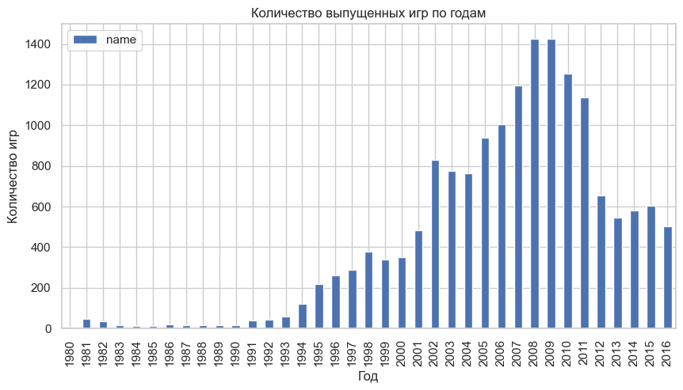

```python
# построим распределение по годам выпуска
games_per_years = data.pivot_table(index='year_of_release', values='name', aggfunc='count')
games_per_years.plot(kind='bar', grid=True, figsize=(10, 5))
plt.title('Количество выпущенных игр по годам')
plt.xlabel('Год')
plt.ylabel('Количество игр')
plt.legend(loc='upper left')
plt.show()
```

На графике мы видим количество игр, выпущенных с 1980 по 2016 год.

С 1980 по 1993 год мы видим минимальное количество выпускаемых игр (менее 100 в год), это легко объяснить отсутствием разнообразия платформ и нехваткой мощностей. Игровая индустрия только начинала свое развитие.

С 1993 года отмечается значительный рост. Это связано с развитием новых технологий на тот момент, например, появляется трёхмерная графика.В 1992-93 годах выходят такие легендарные игры, как `Doom` и `Mortal Kombat`, которые до сих пор пользуются популярностью у миллионов игроков. В 1994 году компания `Sony` выпускает первую игровую консоль `PlayStation`, а в 1995 году проведена первая специализированная выставка индустрии компьютерных видеоигр — Electronic Entertainment Expo (E3). В 1997- 1999 годах наступает эпоха сетевых и онлайн-игр. В эти годы появляются такие игры как `Fallout`, `Half-Life`, `StarCraft`, `Grand Theft Auto (GTA)` и `Counter-Strike`.

В 2000 - 2003 годах появляется новое поколение консолей от компаний `Sony` и `Microsoft`с возможностью сетевой игры и выхода в интернет, появляется больше возможностей, в том числе и технических, для выпуска игр. Выходят такие игры как `The Sims`, `Grand Theft Auto III`, `The Elder Scrolls III: Morrowind`, `Warcraft III` и так далее. Начался бум онлайн игр в Европе и Америке, высокий спрос породил рост выпускаемых игр, что прослеживается на графике.

С 2003 года появляется новая платформа для выпуска игр - мобильные устройства, что дает значительный рост выпускаемых продуктов в эти годы. В 2004 году появляется первая социальная сеть `Facebook` и первый сервис цифрового распространения компьютерных игр – `Steam`. Благодаря появлению `Steam` разработчики игр больше не стали нуждаться в сотрудничестве с крупными издательскими компаниями, это повлекло за собой настоящий бум производства независимых инди игр, что хорошо прослеживается на графике - его пик приходится на 2008-2009 годы. В 2008 году появляются крупные сервисы по продаже мобильных игр: `App Store` и `Android Market` (в 2012 году переименован в Google Play). Наличие таких огромных интернет магазинов в разы увеличило продажи и подстегнуло развитие мобильных видеоигр.

в 2010-11 годах появляется совершенно новый подход - открытый мир с полной свободой действий игрока, где действия персонажа могут влиять на ход развития сюжета (например, `Mass Effect`, `Minecraft` и так далее).

Чем больше развивались технологии, тем больше вопросов приходилось решать игровым студиям: необходимо иметь большой штат специалистов, иметь бюджет на разработку, сюжет, графика и спецэффекты в игре должны заинтересовать и увлечь потенциального покупателя(пользователя), а значит, на разработку игр начало уходить больше времени. Все хотели выпустить хит, который будет продан миллионами копий (например, `The Elder Scrolls V: Skyrim`, `Far Cry 3`, `The Witcher 3: Wild Hunt`). С этим можно связать падение выпускаемых игр с 2012 года.

Предлагаю для анализа использовать период с 2012 года - в этот период в среднем выпускалось по 600 игр в год, полагаю, что данные без аномальных значений помогут составить общую картину.

### Анализ продаж по платформам

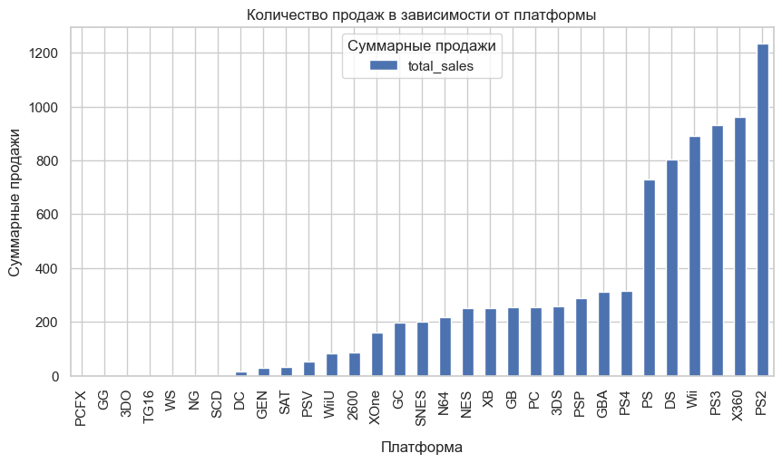

```python
platform_sales = (
    data.pivot_table(index='platform', values='total_sales', aggfunc='sum').sort_values('total_sales', ascending=True)
    .plot(kind='bar', grid=True, figsize=(10, 5)))
plt.title('Количество продаж в зависимости от платформы')
plt.xlabel('Платформа', labelpad=12)
plt.ylabel('Суммарные продажи')
plt.legend(title='Суммарные продажи', loc='upper center')
plt.show()
```

Наибольшие продажи выявлены у платформ: PS, DS, Wii, PS3, X360, PS2.

```python
# определим топ платформ
top_platform = data.pivot_table(index='platform', values='total_sales', aggfunc='sum').sort_values(by='total_sales', ascending=False).reset_index().head(6)['platform'].tolist()
top_platform
```

```
['PS2', 'X360', 'PS3', 'Wii', 'DS', 'PS']
```

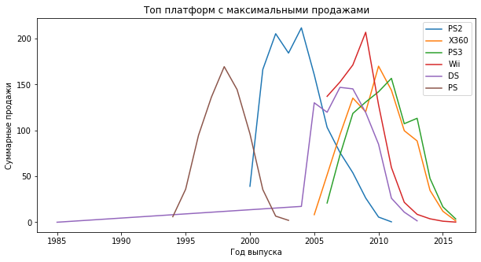

```python
# построим графики для топ-платформ с максимальными продажами
for platform in top_platform:
    (
    data.query('platform == @platform')
    .pivot_table(index = 'year_of_release', values = 'total_sales', aggfunc = 'sum')
    .sort_values('year_of_release', ascending = False)['total_sales']
    .plot(figsize = (10, 5), label=platform)
    )
    plt.title('Топ платформ с максимальными продажами')
    plt.xlabel('Год выпуска')
    plt.ylabel('Суммарные продажи')
    plt.legend()
```

Разберем полученные графики:

Определенно можно заявить, что практически все игровые платформы в среднем существуют до 10 лет включительно. Примерный пик "Популярноси (Продаваемости)" наступает через 3-5 лет после релиза. Самые успешные из них это Sony Play Station и XBOX, у Nintento WII был быстрый скачок в 2009 году и такой же резкий провал. Это неизбежно, т.к. прогресс идет вперед и "железо" в старых консолях перестает отвечать техническим требованиям новых игр.

Также видно, что на графике распределения суммарных продаж по годам для платформы DS имеется выброс, относящийся к 1985 году (сама консоль была выпущена в 2004 году).

```python
# проверим аномальное значение по консоли DS
print(data.query('platform == "DS" and year_of_release < 1990'))
```

```
                                      name platform  year_of_release   genre  \
15957  Strongest Tokyo University Shogi DS       DS             1985  Action

       na_sales  eu_sales  jp_sales  other_sales  critic_score  user_score  \
15957       0.0       0.0      0.02          0.0          -1.0        -1.0

        rating  total_sales
15957  unknown         0.02
```

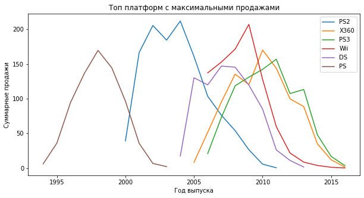

```python
# удалим артефакт и построим график еще раз
data = data.drop(index = 15957)
for platform in top_platform:
    (
    data.query('platform == @platform')
    .pivot_table(index = 'year_of_release', values = 'total_sales', aggfunc = 'sum')
    .sort_values('year_of_release', ascending = False)['total_sales']
    .plot(figsize = (10, 5), label=platform)
    )
    plt.title('Топ платформ с максимальными продажами')
    plt.xlabel('Год выпуска')
    plt.ylabel('Суммарные продажи')
    plt.legend()
```

```python
platform_life = data.pivot_table(index='platform', values='year_of_release', aggfunc=['min', 'max']).reset_index()
# в срок жизни платформы, должны входить границы диапазона, поэтому +1
platform_life['life'] = platform_life['max'] - platform_life['min'] + 1
print('Медианное значение жизненного цикла по всей выборке', platform_life['life'].median(), 'лет')
```

```
Медианное значение жизненного цикла по всей выборке 7.0 лет
```

### Определение актуального периода для анализа данных

Ранее мы приняли решение рассматривать период с 2012 года. Проверим, верное ли было предположение.

```python
t = np.ceil(platform_life['life'].median()/2)
print('Определим актуальный период за последние', t, 'года')
```

```
Определим актуальный период за последние 4.0 года
```

Как уже сказано выше, актуальный период составляет последние 4 года. К тому же, большая часть платформ не акутальна, соответственно, при прогнозе на 17 год их использовать не имеет смысла.

### Анализ потенциально прибыльных платформ

```python
# отберем актуальный период
actual_data = data.query('year_of_release > 2012')
actual_data.sample(5)
```

|  | name | platform | year_of_release | genre | na_sales | eu_sales | jp_sales | other_sales | critic_score | user_score | rating | total_sales |
| --- | --- | --- | --- | --- | --- | --- | --- | --- | --- | --- | --- | --- |
| 5630 | Persona 4: Dancing All Night | PSV | 2015 | Misc | 0.09 | 0.04 | 0.15 | 0.04 | 76.0 | 8.6 | T | 0.32 |
| 7639 | Dying Light | PC | 2015 | Action | 0.12 | 0.06 | 0.00 | 0.02 | 75.0 | 7.9 | M | 0.20 |
| 1658 | WWE 2K16 | PS4 | 2015 | Sports | 0.41 | 0.60 | 0.00 | 0.20 | 73.0 | 7.4 | T | 1.21 |
| 9966 | 2 in 1 Combo Pack: Sonic Heroes / Super Monkey... | X360 | 2013 | Misc | 0.09 | 0.01 | 0.00 | 0.01 | -1.0 | -1.0 | unknown | 0.11 |
| 16459 | Fate/kaleid liner Prisma Illya | 3DS | 2014 | Action | 0.00 | 0.00 | 0.01 | 0.00 | -1.0 | -1.0 | unknown | 0.01 |

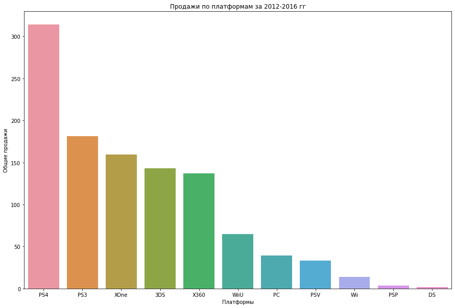

```python
# построим график
actual_platform = (
    actual_data
    .pivot_table(index='platform', values='total_sales', aggfunc='sum')
    .sort_values('total_sales', ascending=False)
)
plt.figure(figsize=(15, 10))
(sns.barplot(data = actual_platform, x = actual_platform.index, y = 'total_sales')
    .set(title = 'Продажи по платформам за 2012-2016 гг', xlabel = 'Платформы', ylabel = 'Общие продажи'))
plt.show()
```

Судя по графику, безоговорочным лидером является `PS4`. Но стоит ли для прогноза на 2017 год убирать из выборки остальные платформы?

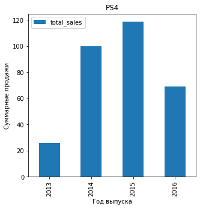

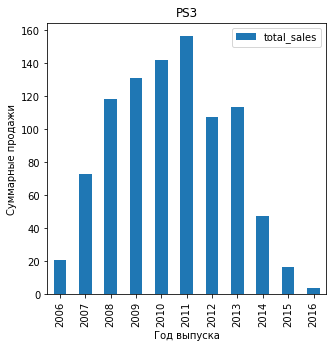

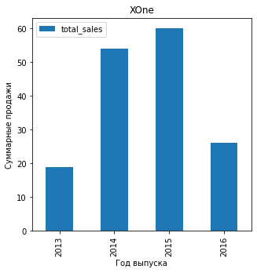

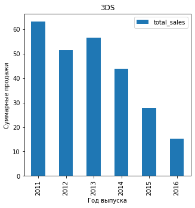

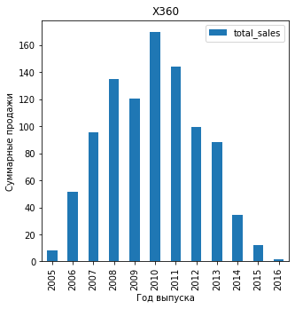

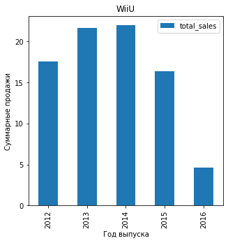

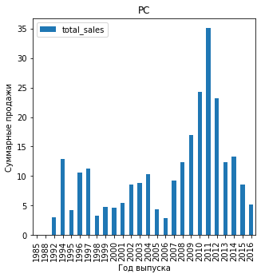

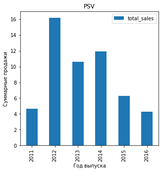

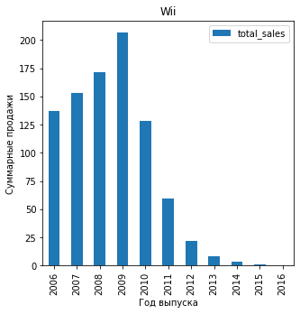

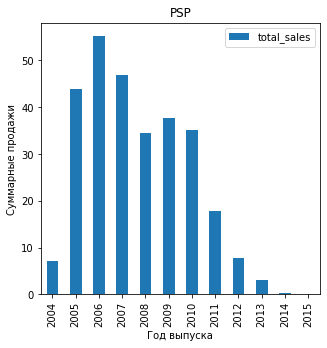

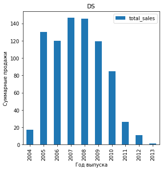

```python
# посмотрим продажи по каждой платформе в актуальный период подробнее

for platform in actual_platform.index:
    (data
     .query('platform == @platform')
     .pivot_table(index='year_of_release', values='total_sales', aggfunc='sum')
     .plot(kind='bar', figsize=(5,5))
    )
    plt.title(platform)
    plt.xlabel('Год выпуска')
    plt.ylabel('Суммарные продажи')
    plt.legend()
    plt.show()
```

В целом, у всех платформ наблюдается спад продаж в выбранный период. Наиболее привлекательные показатели у платформ `PS4` и `XOne` - продажи игр за 2014-2015 годы на этих консолях находятся на пике. Я бы также рассматривала платформу `WiiU` - достаточно хорошие показатели по продажам за актуальный период времени.

Также можно сделать вывод, что в ближайшие годы платформы `PS3` и `X360` покинут рынок, их заменят их новые версии - `PS4` и `XOne`. Но т.к. игры на консолях работают по принципу "обратной совместимости", т.е. игры, выпускаемые на консолях новейшего поколения, также доступны на предыдущих версиях, можно рассматривать `X360` для прогноза на 2017 год. Что касается игр для консолей PlayStation - достоверно известно, что игры предыдущих поколений несовместимы с новыми, соответственно, нет смысла ставить на `PS3` в новом периоде.

**Построим боксплот по глобальным продажам игр в разбивке по платформам.**

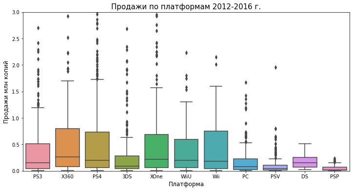

```python
# изучим информацию по всем платформам в выбранный период
plt.figure(figsize=(12,6))
ax = sns.boxplot(data=actual_data, x='platform', y='total_sales')
ax.set(ylim=(0,3))
plt.title('Продажи по платформам 2012-2016 г.', fontsize=15)
plt.xlabel('Платформа', fontsize=12)
plt.ylabel('Продажи млн копий',fontsize=12)
plt.show()
```

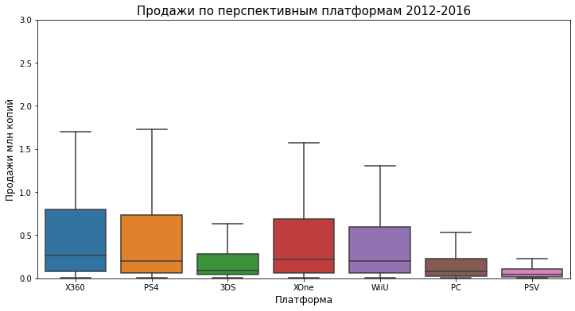

```python
# посмотрим на боксплот только для перспективных платформ
persp_platforms = actual_data.query('year_of_release > 2012 and platform not in ["PS3", "Wii", "PSP", "DS"]')
plt.figure(figsize=(12,6))
ax = sns.boxplot(data=persp_platforms, x='platform', y='total_sales', showfliers=False)
ax.set(ylim=(0,3))
plt.title('Продажи по перспективным платформам 2012-2016', fontsize=15)
plt.xlabel('Платформа', fontsize=12)
plt.ylabel('Продажи млн копий',fontsize=12)
plt.show()
```

**Вывод:**

Отличные показатели у платформ Microsoft и Sony. Распределения для `PS4` и `XOne` похожи, медианы находятся практически на одном уровне, размах "усов" тоже практически совпадает. Для WiiU медиана чуть меньше, как и размах "усов".

Платформы `3DS`, `PSV` вышли недавно, можно сделать на них ставку на ближайший год.

Исходя из этого, можно сделать вывод о том, что для планирования рекламной кампании на 2017 можем выбрать все эти платформы.

### Влияние на продажи отзывов пользователей и критиков

Рассмотрим в рамках следующих платформ - PS4, XOne и WiiU.

```python
# избавимся сначала от значений-заглушек
ps4 = actual_data.query('platform == "PS4" & user_score != -1 & critic_score != -1')
```

```
Коэфициент корреляции продаж и отзывов критиков: 0.51
```

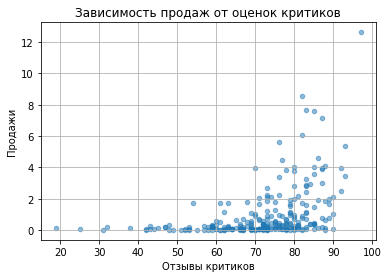

```python
# диаграмма рассеяния для суммарных продаж и отзывов критиков для PS4

ps4.plot(x='critic_score', y='total_sales', kind='scatter', alpha=0.5, grid = True)
plt.title('Зависимость продаж от оценок критиков')
plt.xlabel('Отзывы критиков')
plt.ylabel('Продажи')

print('Коэфициент корреляции продаж и отзывов критиков:', "{:.2f}".format(ps4['total_sales'].corr(ps4['critic_score'], method='spearman')))
```

```
Коэфициент корреляции продаж и отзывов пользователей: -0.03
```

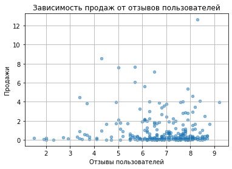

```python
# диаграмма рассеяния для суммарных продаж и отзывов пользователей для PS4
ps4.plot(x='user_score', y='total_sales', kind='scatter', alpha=0.5, grid = True)
plt.title('Зависимость продаж от отзывов пользователей')
plt.xlabel('Отзывы пользователей')
plt.ylabel('Продажи')

print('Коэфициент корреляции продаж и отзывов пользователей:', "{:.2f}".format(ps4['total_sales'].corr(ps4['user_score'], method='spearman')))
```

**Можно сделать вывод, что отзывы пользователей не влияют на продажи, так как значение отрицательное. Также у пользователей больше отрицательных оценок, чем у критиков.**

**Отзывы критиков оказывают на продажи небольшое влияние, это видно по корреляции в 51 процент. Зависимость прослеживается - чем выше оценка критиков, тем больше происходит продаж.**

```python
# избавимся сначала от значений-заглушек
xone = actual_data.query('platform == "XOne" & user_score != -1 & critic_score != -1')
```

```
Коэфициент корреляции продаж и отзывов критиков: 0.53
```

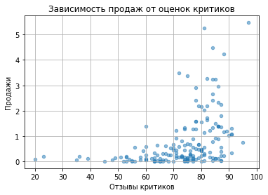

```python
# диаграмма рассеяния для суммарных продаж и отзывов критиков для XOne
xone.plot(x='critic_score', y='total_sales', kind='scatter', alpha=0.5, grid = True)
plt.title('Зависимость продаж от оценок критиков')
plt.xlabel('Отзывы критиков')
plt.ylabel('Продажи')

print('Коэфициент корреляции продаж и отзывов критиков:', "{:.2f}".format(xone['total_sales'].corr(xone['critic_score'], method='spearman')))
```

```
Коэфициент корреляции продаж и отзывов пользователей: -0.12
```

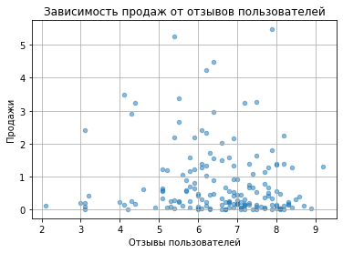

```python
# диаграмма рассеяния для суммарных продаж и отзывов пользователей для XOne
xone.plot(x='user_score', y='total_sales', kind='scatter', alpha=0.5, grid = True)
plt.title('Зависимость продаж от отзывов пользователей')
plt.xlabel('Отзывы пользователей')
plt.ylabel('Продажи')

print('Коэфициент корреляции продаж и отзывов пользователей:', "{:.2f}".format(xone['total_sales'].corr(xone['user_score'], method='spearman')))
```

**В целом, картина та же, что и с платформой PS4. Прослеживается зависимость между оценками критиков и продажами.**

```python
# избавимся сначала от значений-заглушек
wiiu = actual_data.query('platform == "WiiU" & user_score != -1 & critic_score != -1')
```

```
Коэфициент корреляции продаж и отзывов критиков: 0.47
```

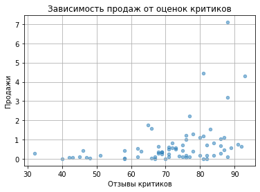

```python
# диаграмма рассеяния для суммарных продаж и отзывов критиков для WiiU
wiiu.plot(x='critic_score', y='total_sales', kind='scatter', alpha=0.5, grid = True)
plt.title('Зависимость продаж от оценок критиков')
plt.xlabel('Отзывы критиков')
plt.ylabel('Продажи')

print('Коэфициент корреляции продаж и отзывов критиков:', "{:.2f}".format(wiiu['total_sales'].corr(wiiu['critic_score'], method='spearman')))
```

```
Коэфициент корреляции продаж и отзывов пользователей: 0.47
```

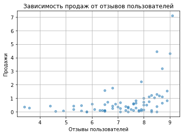

```python
# диаграмма рассеяния для суммарных продаж и отзывов пользователей для WiiU
wiiu.plot(x='user_score', y='total_sales', kind='scatter', alpha=0.5, grid = True)
plt.title('Зависимость продаж от отзывов пользователей')
plt.xlabel('Отзывы пользователей')
plt.ylabel('Продажи')

print('Коэфициент корреляции продаж и отзывов пользователей:', "{:.2f}".format(wiiu['total_sales'].corr(wiiu['user_score'], method='spearman')))
```

**А вот здесь ситуация немного меняется: и оценки критиков, и оценки пользователей оказывают небольшое влияние на продажи - 47%**

Можно предположить, что портативная консоль сама по себе уже является хорошей рекламой, больше возможностей для демонстрации игры, а значит и больше продаж.

### Общее распределение игр по жанрам

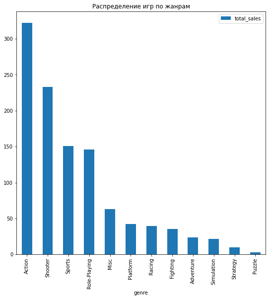

```python
# создадим сводную таблицу с продажами игр по жанрам

games_genre = (
    actual_data
    .pivot_table(index = 'genre', values = 'total_sales', aggfunc = 'sum')
    .sort_values(by = 'total_sales', ascending = False)
    .plot(
        kind='bar',
        figsize=(9,9),
        title = ('Распределение игр по жанрам')));
```

Наиболее прибыльные жанры - `Action`, `Shooter`, наименее прибыльный - `Puzzle`. Также хорошо продаются игры в жанре `Sports`, `Role-Playing`.

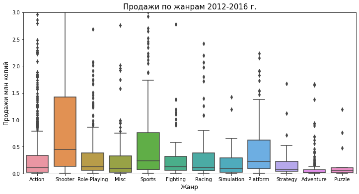

```python
# подбор жанров для продажи
plt.figure(figsize=(12,6))
ax = sns.boxplot(data=actual_data, x='genre', y='total_sales')
ax.set(ylim=(0,3))
plt.title('Продажи по жанрам 2012-2016 г.', fontsize=15)
plt.xlabel('Жанр', fontsize=12)
plt.ylabel('Продажи млн копий',fontsize=12)
plt.show()
```

```python
# найдем медианные продажи по жанрам
games_genre_median = actual_data.pivot_table(index='genre', values='total_sales', aggfunc='median')
games_genre_median.columns = ['median_sales']
games_genre_median.sort_values(by='median_sales', ascending=False)
```

| genre | median_sales |
| --- | --- |
| Shooter | 0.450 |
| Sports | 0.240 |
| Platform | 0.225 |
| Role-Playing | 0.125 |
| Fighting | 0.125 |
| Racing | 0.120 |
| Action | 0.110 |
| Simulation | 0.100 |
| Misc | 0.100 |
| Strategy | 0.080 |
| Puzzle | 0.060 |
| Adventure | 0.030 |

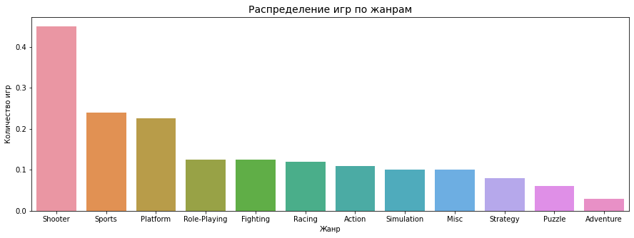

```python
# построим график
plt.figure(figsize=(15, 5))
games_genre_median = games_genre_median.sort_values(by='median_sales', ascending=False)
fig = sns.barplot(x=games_genre_median.index, y='median_sales', data=games_genre_median)
fig.set_title('Распределение игр по жанрам', fontsize=14)
fig.set_xlabel('Жанр')
fig.set_ylabel('Количество игр')
plt.show()
```

**Промежуточный вывод:**

## Портреты пользователей по регионам

### ТОП-5 популярных платформ

```python
# найдем топ-5 платформ в регионах

na_sales = actual_data.pivot_table(index='platform', values='na_sales', aggfunc='sum').nlargest(5, 'na_sales').reset_index()

eu_sales = actual_data.pivot_table(index='platform', values='eu_sales', aggfunc='sum').nlargest(5, 'eu_sales').reset_index()

jp_sales = actual_data.pivot_table(index='platform', values='jp_sales', aggfunc='sum').nlargest(5, 'jp_sales').reset_index()
```

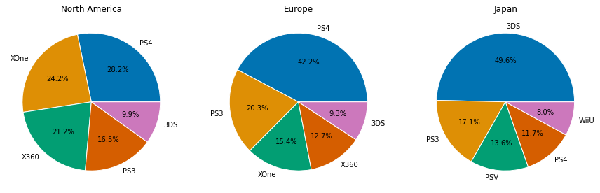

```python
# построим круговые диаграммы

fig, axes = plt.subplots(1, 3, figsize=(15, 5))

na_sales.plot(
    kind='pie', y='na_sales', colors = sns.color_palette('colorblind'),
    autopct='%.1f%%', ax=axes[0], legend=False, wedgeprops={'lw':1, 'ls':'-','edgecolor':"white"},
    labels=na_sales['platform']).set(ylabel='', title='North America');

eu_sales.plot(
    kind='pie', y='eu_sales', colors = sns.color_palette('colorblind'),
    autopct='%.1f%%', ax=axes[1], legend=False, wedgeprops={'lw':1, 'ls':'-','edgecolor':"white"},
    labels=eu_sales['platform']).set(ylabel='', title='Europe');

jp_sales.plot(
    kind='pie', y='jp_sales', colors = sns.color_palette('colorblind'),
    autopct='%.1f%%', ax=axes[2], legend=False, wedgeprops={'lw':1, 'ls':'-','edgecolor':"white"},
    labels=jp_sales['platform']).set(ylabel='', title='Japan');

plt.show()
```

**Вывод:**

1. В Европе наиболее популярны платформы от компании Sony - безоговорочный лидер консоль PS4 (42,2%), консоль предыдущего поколения PS3 идет следом. Продукты от Microsoft (XOne, X360) менее популярны среди пользователей, но занимают довольно большую долю рынка.
2. Пользователи в Северной Америке также отдают предпочтение консоли PS4, однако доля пользователей платформами от Microsoft значительно выше, чем в Европе.
3. В Японии больше половины рынка занимают портативные консоли Nintendo (3DS, WiiU - 57,6%).

Пользователи в Северной Америке и Европе отдают предпочтение стационарным платформам, тогда как в Японии предпочитают "карманный" вариант.

### ТОП-5 популярных жанров

```python
# найдем топ-5 жанров в регионах

na_sales = actual_data.pivot_table(index='genre', values='na_sales', aggfunc='sum').nlargest(5, 'na_sales').reset_index()

eu_sales = actual_data.pivot_table(index='genre', values='eu_sales', aggfunc='sum').nlargest(5, 'eu_sales').reset_index()

jp_sales = actual_data.pivot_table(index='genre', values='jp_sales', aggfunc='sum').nlargest(5, 'jp_sales').reset_index()
```

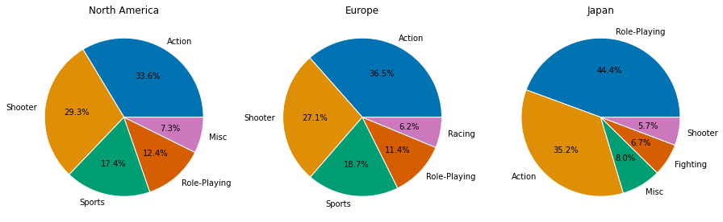

```python
# построим круговые диаграммы

fig, axes = plt.subplots(1, 3, figsize=(15, 5))

na_sales.plot(
    kind='pie', y='na_sales', colors = sns.color_palette('colorblind'),
    autopct='%.1f%%', ax=axes[0], legend=False, wedgeprops={'lw':1, 'ls':'-','edgecolor':"white"},
    labels=na_sales['genre']).set(ylabel='', title='North America');

eu_sales.plot(
    kind='pie', y='eu_sales', colors = sns.color_palette('colorblind'),
    autopct='%.1f%%', ax=axes[1], legend=False, wedgeprops={'lw':1, 'ls':'-','edgecolor':"white"},
    labels=eu_sales['genre']).set(ylabel='', title='Europe');

jp_sales.plot(
    kind='pie', y='jp_sales', colors = sns.color_palette('colorblind'),
    autopct='%.1f%%', ax=axes[2], legend=False, wedgeprops={'lw':1, 'ls':'-','edgecolor':"white"},
    labels=jp_sales['genre']).set(ylabel='', title='Japan');

plt.show()
```

**Вывод:**

1. В Европе и Северной Америке примерно одинаково популярны игры в жанрах Action и Shooter, а также Sports (FIFA, Call of Duty)
2. Япония является прародителем жанра RPG (в частности, jRPG), неудивительно, что эти игры очень популярны среди местных пользователей (например, Final Fantasy, Pokemon, Legend of Heroes и Persona.)

Позже, игры, выпущенные изначально только для японского рынка, начинают завоевывать популярность и в других регионах. Мы видим, что они занимают приличную долю рынка в Европе и СА.

### Влияние рейтинга ESRB на продажи в отдельном регионе

*Entertainment Software Rating Board (ESRB)* — негосударственная организация, основное направление деятельности — принятие и определение рейтингов для компьютерных видеоигр и другого развлекательного программного обеспечения в США и Канаде.

- «E» («Everyone») — «Для всех»
- «E10+» («Everyone 10 and older») — «Для всех от 10 лет и старше».
- «T» («Teen») — «Подросткам»: Игра подходит для лиц от 13 лет.
- «M» («Mature») — «Для взрослых»: Материалы игры не подходят для лиц младше 17 лет.

```python
actual_data['rating'].unique()
```

```
array(['M', 'unknown', 'E', 'T', 'E10+'], dtype=object)
```

Ранее мы заполнили пропущенные значения в 'rating' значением 'unknown'.

```python
na_sales = actual_data.pivot_table(index='rating', values='na_sales', aggfunc='sum').nlargest(5, 'na_sales').reset_index()

eu_sales = actual_data.pivot_table(index='rating', values='eu_sales', aggfunc='sum').nlargest(5, 'eu_sales').reset_index()

jp_sales = actual_data.pivot_table(index='rating', values='jp_sales', aggfunc='sum').nlargest(5, 'jp_sales').reset_index()
```

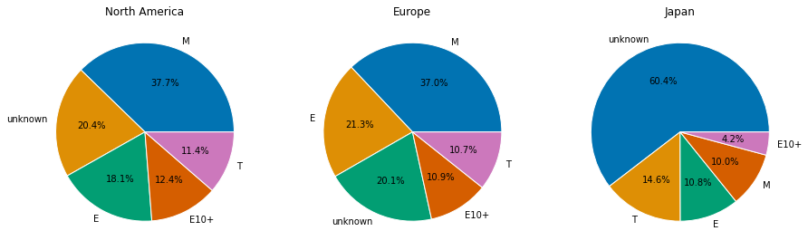

```python
# построим круговые диаграммы

fig, axes = plt.subplots(1, 3, figsize=(15, 5))

na_sales.plot(
    kind='pie', y='na_sales', colors = sns.color_palette('colorblind'),
    autopct='%.1f%%', ax=axes[0], legend=False, wedgeprops={'lw':1, 'ls':'-','edgecolor':"white"},
    labels=na_sales['rating']).set(ylabel='', title='North America');

eu_sales.plot(
    kind='pie', y='eu_sales', colors = sns.color_palette('colorblind'),
    autopct='%.1f%%', ax=axes[1], legend=False, wedgeprops={'lw':1, 'ls':'-','edgecolor':"white"},
    labels=eu_sales['rating']).set(ylabel='', title='Europe');

jp_sales.plot(
    kind='pie', y='jp_sales', colors = sns.color_palette('colorblind'),
    autopct='%.1f%%', ax=axes[2], legend=False, wedgeprops={'lw':1, 'ls':'-','edgecolor':"white"},
    labels=jp_sales['rating']).set(ylabel='', title='Japan');

plt.show()
```

**Вывод:**

1. В Северной Америке и Европе рейтинги достаточно близки друг к другу. Первые места заняли игры категории М ("Mature" - от 17 лет), E ("Everyone" - для всех),последние - Е10+ ("Everyone 10 and older" - от 10 лет) и Т ("Teen" - от 13 лет). Для Северной Америки игры без указанной категории заняли второе место по числу проданных копий, для Европы - третье.
2. В Японии первое место по количеству проданных копий заняли игры без определенного рейтинга (скорее всего потому, что в Японии действует своя ассоциация по определению возрастного рейтинга игр - CERO). Далее по популярности в отличие от других регонов располагаются игры категорий Т, Е, М и Е10+.

Если рассматривать вопрос о том, влияет ли рейтинг ESRB на продажи в каждом регионе, можно сказать, что он наибольшим образом влияет на игры, продаваемые в Северной Америке и Европе.

**Вывод по разделу:**

1. Портрет пользователя из Северной Америки:
   - предпочитает консоль PS4 / XOne;
   - играет в игры жанра `Shooter` / `Action`;
   - играет в игры категории 'M'.
2. Портрет пользователя из Европы:
   - предпочитает консоль PS4 / PS3;
   - играет в игры жанра `Shooter` / `Action`;
   - играет в игры категории 'M' / 'E'.
3. Портрет пользователя из Японии:
   - предпочитает портативную консоль 3DS;
   - любит игры в жанре `RPG`;
   - играет в игры без возрастного рейтинга.

## Проверка гипотез

1. Средние пользовательские рейтинги платформ Xbox One и PC одинаковые;
2. Средние пользовательские рейтинги жанров Action (англ. «действие», экшен-игры) и Sports (англ. «спортивные соревнования») разные.
- Так как мы проверяем две независимые выборки о равенстве двух генеральных совокупностей, то применим метод `st.ttest_ind`.
- Примем значение p-value в 5%.

### Средние пользовательские рейтинги платформ Xbox One и PC одинаковые

**Гипотеза Н0 (нулевая гипотеза)** - средние пользовательские рейтинги платформ Xbox One и PC одинаковые.

**Гипотеза H1 (альтернативная гипотеза)** - средний пользовательский рейтинг платформы Xbox One > PC.

```python
# посчитаем средний пользовательский рейтинг платформы XOne

xone = (actual_data[(actual_data['platform'] == 'XOne') & (actual_data['user_score'] > 0)]['user_score'])
xone.mean().round(2)
```

```
6.52
```

```python
# посчитаем средний пользовательский рейтинг платформы PC

pc = (actual_data[(actual_data['platform'] == 'PC') & (actual_data['user_score'] > 0)]['user_score'])
pc.mean().round(2)
```

```
6.27
```

```python
# проверим гипотезы

alpha = .05

results = st.ttest_ind(xone, pc, alternative='greater')

print('p-значение:', results.pvalue)

if results.pvalue < alpha:
    print("Отвергаем нулевую гипотезу")
else:
    print("Не получилось отвергнуть нулевую гипотезу")
```

```
p-значение: 0.07006382605008392
Не получилось отвергнуть нулевую гипотезу
```

Нулевая гипотеза не была отвергнута, значит, нет оснований полагать, что рейтинги платформ Xbox One и PC отличаются.

### Средние пользовательские рейтинги жанров Action и Sports разные.

**Гипотеза Н0 (нулевая гипотеза)** - средние пользовательские рейтинги жанров Action и Sports одинаковые.

```python
# посчитаем средний пользовательский рейтинг жанра Action

action = (actual_data[(actual_data['genre'] == 'Action') & (actual_data['user_score'] > 0)]['user_score'])
action.mean().round(2)
```

```
6.84
```

```python
# посчитаем средний пользовательский рейтинг жанра Sports

sports = (actual_data[(actual_data['genre'] == 'Sports') & (actual_data['user_score'] > 0)]['user_score'])
sports.mean().round(2)
```

```
5.24
```

```python
# проверим гипотезы

alpha = .05

results = st.ttest_ind(action, sports, alternative='greater')

print('p-значение:', results.pvalue)

if results.pvalue < alpha:
    print("Отвергаем нулевую гипотезу")
else:
    print("Не получилось отвергнуть нулевую гипотезу")
```

```
p-значение: 5.258886005704227e-28
Отвергаем нулевую гипотезу
```

Нулевая гипотеза отвергнута, средние пользовательские рейтинги жанров Action и Sports разные.

**Вывод по итогам проверки гипотез:**

1. Нулевая гипотеза не была отвергнута, значит, нет оснований полагать, что рейтинги платформ Xbox One и PC отличаются.
2. Нулевая гипотеза отвергнута, средние пользовательские рейтинги жанров Action и Sports разные.

## Общий вывод

В рамках подготовки к рекламной кампании на 2017 год были исследованы данные, полученные из открытых источников: исторические данные о продажах игр, оценки пользователей и экспертов, жанры и платформы (например, Xbox или PlayStation). В процессе исследования были выявлены закономерности, определяющие успешность игры .

В целях увеличения прибыли интернет магазина "Стримчик" необходимо запланировать проведение рекламных компаний игр на потенциально популярные продукты: